# Design 2: Inequality Belief Systems and Attitude Towards Redistribution in US and the Netherlands

# Design 2 (based on van den Hoogen et al 2022)

- [Paper link](https://journals.sagepub.com/doi/10.1177/14651165221101505)

## Analysis structure

- CCA (perceptions and beliefs about inequality; with preference for redistribution)
- EGA: CCA group 1 vs CCA group 2 (by country)
- Histogram of preference for redistribution by CCA groups
- Regression (on high high preference for redistribution sample): sociodem + determinants of preference for redistribution (i.e.: party id, social homophily) -> CCA

# Variables

| variable | label |
| --- | --- |
| perc_income | Differences in income in the United States are too large |
| perc_wealth | Differences in wealth in the United States are too large |
| perc_poor | Children in poor families do not have the same opportunities for getting ahead a |
| perc_black | Black children do not have the same opportunities for getting ahead as white chi |
| bel_merit | Society is fair when hard-working people earn more than others |
| bel_diversity | Racial diversity makes America stronger |
| bel_equality | For society to be fair, differences in people’s standard of living should be sma |
| ib_weafam | coming from a wealthy family |
| ib_edupar | having highly educated parents |
| ib_edu | having a good education |
| ib_work | hard work |
| ib_people | knowing the right people |
| ib_race | race or skin color |
| ib_migra | legal or immigration status |
| ib_relig | religion |
| ib_sex | being born a man or woman |
| att_redist | It is the responsibility of the government to reduce the differences in income b |

## Descriptives

### US

```
##
## ==================================================
## Statistic         N     Mean    St. Dev. Min  Max
## --------------------------------------------------
## nomem_encr      2,479 1,252.175 722.849   1  2,505
## survey          2,479   1.401    0.490    1    2
## country         2,479   1.000    0.000    1    1
## treatment       2,479   1.201    1.169    0    3
## age             2,479  43.538    16.174  18   84
## agegroups       2,479   3.050    1.502    1    5
## education       2,479   2.583    0.682    1    3
## working         2,479   0.650    0.477    0    1
## politics        2,479   3.873    2.938    0   10
## pol5            2,479   2.522    1.238    1    5
## hhincome        2,479   6.331    3.243    1   11
## assets          2,479   3.140    1.909    0    7
## immigrant       2,479   0.075    0.263    0    1
## marital         2,479   0.472    0.499    0    1
## ladder_present  2,479   4.153    1.112    1    7
## perc_income     2,479   5.731    1.403    1    7
## perc_wealth     2,479   5.889    1.420    1    7
## perc_poor       2,479   5.971    1.364    1    7
## perc_black      2,479   5.322    1.701    1    7
## bel_merit       2,479   4.922    1.392    1    7
## bel_diversity   2,479   5.741    1.457    1    7
## bel_equality    2,479   4.885    1.576    1    7
## ib_weafam       2,479   3.509    0.979    1    5
## ib_edupar       2,479   3.411    0.931    1    5
## ib_edu          2,479   4.052    0.790    1    5
## ib_work         2,479   4.048    0.954    1    5
## ib_people       2,479   3.857    0.925    1    5
## ib_race         2,479   2.904    1.179    1    5
## ib_migra        2,479   3.567    1.070    1    5
## ib_relig        2,479   2.001    1.030    1    5
## ib_sex          2,479   2.714    1.163    1    5
## att_redist      2,479   4.950    1.844    1    7
## att_discrim     2,479   5.696    1.553    1    7
## hhincome_groups 2,479   2.200    0.651    1    3
## CCA             2,479   0.472    0.499    0    1
## --------------------------------------------------
```

### NL

```
##
## ============================================================
## Statistic         N      Mean      St. Dev.    Min     Max
## ------------------------------------------------------------
## nomem_encr      1,452 848,800.600 29,034.480 800,057 899,794
## survey          1,452    1.000      0.000       1       1
## country         1,452    2.000      0.000       2       2
## treatment       1,452    1.003      0.818       0       2
## age             1,452   57.738      16.816     18      92
## agegroups       1,452    4.081      1.282       1       5
## education       1,452    2.337      0.883       1       3
## working         1,452    0.429      0.495       0       1
## politics        1,452    5.202      2.095       0      10
## pol5            1,452    3.060      0.867       1       5
## hhincome        1,452    5.120      2.388       1       9
## assets          1,452    3.388      1.402       0       7
## immigrant       1,452    0.079      0.270       0       1
## marital         1,452    0.567      0.496       0       1
## ladder_present  1,452    4.867      1.031       1       7
## perc_income     1,452    5.021      1.405       1       7
## perc_wealth     1,452    5.187      1.396       1       7
## perc_poor       1,452    5.242      1.343       1       7
## perc_black      1,452    4.634      1.493       1       7
## bel_merit       1,452    3.382      1.596       1       7
## bel_diversity   1,452    3.667      1.574       1       7
## bel_equality    1,452    4.379      1.491       1       7
## ib_weafam       1,452    2.856      0.862       1       5
## ib_edupar       1,452    3.163      0.763       1       5
## ib_edu          1,452    3.696      0.713       1       5
## ib_work         1,452    3.691      0.783       1       5
## ib_people       1,452    3.488      0.760       1       5
## ib_race         1,452    2.491      0.953       1       5
## ib_migra        1,452    2.600      0.925       1       5
## ib_relig        1,452    1.833      0.752       1       5
## ib_sex          1,452    2.193      0.884       1       5
## att_redist      1,452    5.039      1.457       1       7
## att_discrim     1,452    5.681      1.242       1       7
## hhincome_groups 1,452    1.724      0.545       1       3
## CCA             1,452    0.477      0.500       0       1
## ------------------------------------------------------------
```

# Inequality Belief Systems

## Distribution

### US

```
## CCA <numeric>
## # total N=2479 valid N=2479 mean=0.47 sd=0.50
##
## Value |    N | Raw % | Valid % | Cum. %
## ---------------------------------------
##     0 | 1310 | 52.84 |   52.84 |  52.84
##     1 | 1169 | 47.16 |   47.16 | 100.00
##  <NA> |    0 |  0.00 |    <NA> |   <NA>
```

### NL

```
## CCA <numeric>
## # total N=1452 valid N=1452 mean=0.48 sd=0.50
##
## Value |   N | Raw % | Valid % | Cum. %
## --------------------------------------
##     0 | 759 | 52.27 |   52.27 |  52.27
##     1 | 693 | 47.73 |   47.73 | 100.00
##  <NA> |   0 |  0.00 |    <NA> |   <NA>
```

## EGA

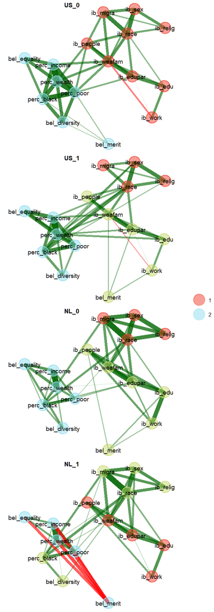

# Inequality Belief Systems and Attitude Towards Redistribution

## Graphs

### US

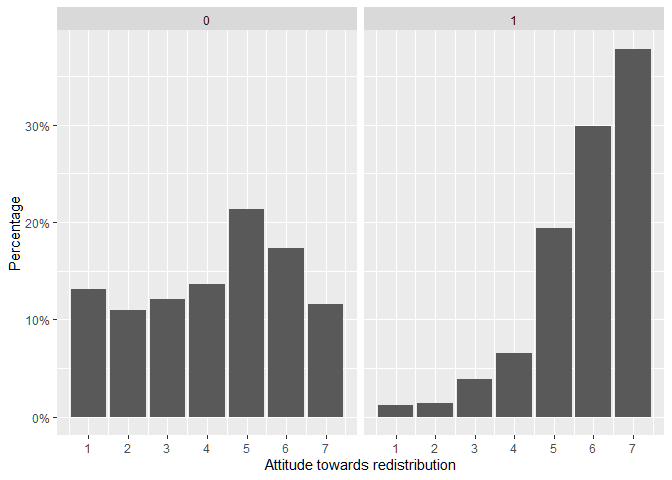

### NL

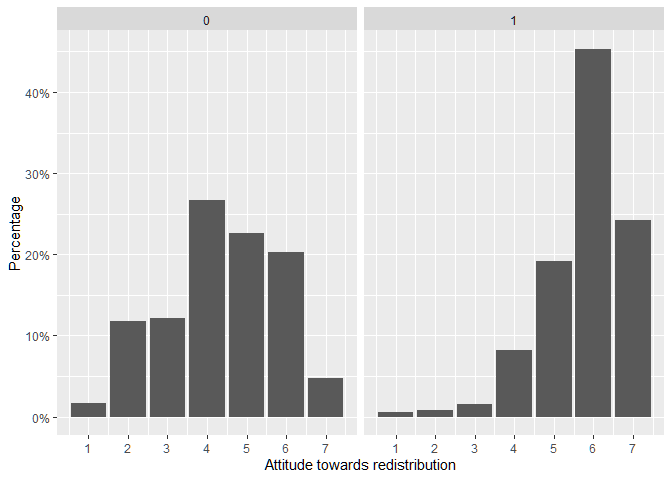

# Sociodemographic Determinants of Inequality Belief Systems

## Regressions

### Full sample

Table. Logistic regression models on the probability to be a member of the CCA group 1 (CCA) - US & NL (Full sample)

M1_US

M2_US

M3_US

M1_NL

M2_NL

M3_NL

Odds Ratios

Odds Ratios

Odds Ratios

Odds Ratios

Odds Ratios

Odds Ratios

(Intercept)

3.48 ***  
(2.99 – 4.05)

2.74 ***  
(1.71 – 4.41)

0.71  
(0.47 – 1.09)

3.30 ***  
(2.46 – 4.46)

3.69 ***  
(1.84 – 7.45)

0.93  
(0.50 – 1.71)

Political orientation

0.69 ***  
(0.67 – 0.72)

0.71 ***  
(0.68 – 0.74)

0.78 ***  
(0.74 – 0.82)

0.78 ***  
(0.73 – 0.82)

agegroups28-37

1.15  
(0.86 – 1.54)

1.16  
(0.88 – 1.52)

0.86  
(0.48 – 1.55)

0.85  
(0.48 – 1.51)

agegroups38-47

1.61 ***  
(1.17 – 2.22)

1.43 **  
(1.07 – 1.92)

1.07  
(0.59 – 1.93)

1.05  
(0.59 – 1.86)

agegroups48-57

1.35 *  
(0.96 – 1.89)

1.33 *  
(0.98 – 1.82)

1.06  
(0.61 – 1.84)

1.09  
(0.63 – 1.87)

Age(in groups): 58+

1.65 ***  
(1.23 – 2.22)

1.54 ***  
(1.18 – 2.03)

1.26  
(0.74 – 2.13)

1.41  
(0.85 – 2.35)

sexMale

0.86  
(0.72 – 1.04)

0.70 ***  
(0.59 – 0.82)

1.32 **  
(1.04 – 1.68)

1.18  
(0.94 – 1.48)

raceWhite

0.85  
(0.68 – 1.05)

0.74 ***  
(0.60 – 0.90)

1.07  
(0.70 – 1.61)

1.04  
(0.70 – 1.55)

education: Some college

1.46 **  
(1.04 – 2.05)

1.61 ***  
(1.18 – 2.21)

0.68 *  
(0.45 – 1.02)

0.73  
(0.49 – 1.07)

education: College or  
more

1.64 ***  
(1.20 – 2.25)

1.92 ***  
(1.44 – 2.57)

0.85  
(0.65 – 1.11)

0.92  
(0.71 – 1.20)

working

0.91  
(0.74 – 1.13)

0.87  
(0.72 – 1.06)

0.80  
(0.60 – 1.06)

0.77 *  
(0.58 – 1.01)

assets

0.93 **  
(0.88 – 0.99)

0.96  
(0.91 – 1.01)

0.98  
(0.90 – 1.07)

0.95  
(0.87 – 1.04)

hhincome groups: Medium

0.60 ***  
(0.45 – 0.81)

0.66 ***  
(0.50 – 0.87)

1.02  
(0.78 – 1.34)

1.10  
(0.85 – 1.43)

hhincome groups: High

0.51 ***  
(0.36 – 0.72)

0.54 ***  
(0.39 – 0.74)

0.51 **  
(0.27 – 0.94)

0.55 *  
(0.30 – 1.00)

immigrant

0.79  
(0.56 – 1.11)

0.86  
(0.62 – 1.19)

0.79  
(0.50 – 1.25)

0.88  
(0.56 – 1.37)

marital

0.98  
(0.79 – 1.21)

0.80 **  
(0.66 – 0.98)

1.01  
(0.79 – 1.29)

0.96  
(0.76 – 1.22)

religionNone

2.15 ***  
(1.65 – 2.80)

3.28 ***  
(2.58 – 4.18)

0.91  
(0.65 – 1.27)

1.06  
(0.76 – 1.46)

religionOther

1.44 **  
(1.07 – 1.94)

1.68 ***  
(1.28 – 2.21)

0.88  
(0.38 – 2.01)

1.17  
(0.53 – 2.62)

religionProtestant

1.35 **  
(1.01 – 1.80)

1.14  
(0.88 – 1.48)

1.01  
(0.67 – 1.53)

1.00  
(0.67 – 1.50)

Observations

2479

2479

2479

1452

1452

1452

R<sup>2</sup> Tjur

0.205

0.238

0.097

0.060

0.085

0.029

AIC

2889.329

2823.069

3215.666

1924.663

1920.714

2003.982

- p<0.1 ** p<0.05 *** p<0.01

### High preference for redistribution

Table. Logistic regression models on the probability to be a member of the CCA group 1 (CCA) - US & NL (High preference for redistribution [>4])

M1_US

M2_US

M3_US

M1_NL

M2_NL

M3_NL

Odds Ratios

Odds Ratios

Odds Ratios

Odds Ratios

Odds Ratios

Odds Ratios

(Intercept)

3.98 ***  
(3.36 – 4.73)

2.75 ***  
(1.56 – 4.91)

1.02  
(0.60 – 1.74)

3.32 ***  
(2.37 – 4.70)

1.94  
(0.81 – 4.68)

0.84  
(0.39 – 1.83)

Political orientation

0.74 ***  
(0.71 – 0.77)

0.77 ***  
(0.74 – 0.81)

0.87 ***  
(0.81 – 0.93)

0.86 ***  
(0.81 – 0.92)

agegroups28-37

1.19  
(0.86 – 1.65)

1.25  
(0.91 – 1.71)

0.70  
(0.33 – 1.47)

0.69  
(0.33 – 1.44)

agegroups38-47

1.96 ***  
(1.36 – 2.84)

1.81 ***  
(1.28 – 2.56)

1.12  
(0.53 – 2.38)

1.10  
(0.52 – 2.31)

agegroups48-57

1.62 **  
(1.08 – 2.45)

1.97 ***  
(1.33 – 2.93)

0.80  
(0.40 – 1.59)

0.82  
(0.41 – 1.62)

Age(in groups): 58+

2.11 ***  
(1.47 – 3.04)

2.60 ***  
(1.84 – 3.70)

0.94  
(0.49 – 1.81)

1.02  
(0.53 – 1.94)

sexMale

0.80 *  
(0.64 – 1.00)

0.68 ***  
(0.55 – 0.84)

1.14  
(0.85 – 1.54)

1.07  
(0.80 – 1.43)

raceWhite

1.06  
(0.83 – 1.36)

1.00  
(0.79 – 1.27)

1.30  
(0.80 – 2.11)

1.30  
(0.80 – 2.10)

education: Some college

1.10  
(0.71 – 1.70)

1.16  
(0.76 – 1.77)

0.78  
(0.47 – 1.29)

0.85  
(0.52 – 1.41)

education: College or  
more

1.23  
(0.82 – 1.85)

1.30  
(0.87 – 1.92)

1.03  
(0.74 – 1.42)

1.12  
(0.81 – 1.54)

working

0.94  
(0.72 – 1.23)

0.86  
(0.67 – 1.12)

0.77  
(0.54 – 1.09)

0.76  
(0.54 – 1.07)

assets

0.97  
(0.90 – 1.04)

1.01  
(0.94 – 1.08)

1.07  
(0.95 – 1.19)

1.05  
(0.94 – 1.18)

hhincome groups: Medium

0.63 **  
(0.44 – 0.90)

0.69 **  
(0.49 – 0.97)

1.05  
(0.75 – 1.46)

1.11  
(0.80 – 1.55)

hhincome groups: High

0.53 ***  
(0.35 – 0.79)

0.54 ***  
(0.37 – 0.80)

0.71  
(0.31 – 1.68)

0.80  
(0.35 – 1.86)

immigrant

0.69 *  
(0.47 – 1.02)

0.74  
(0.51 – 1.09)

0.57 **  
(0.33 – 0.98)

0.61 *  
(0.36 – 1.04)

marital

0.79 *  
(0.61 – 1.03)

0.66 ***  
(0.51 – 0.85)

1.04  
(0.77 – 1.41)

1.04  
(0.77 – 1.40)

religionNone

2.33 ***  
(1.71 – 3.17)

3.23 ***  
(2.42 – 4.33)

1.37  
(0.92 – 2.06)

1.50 **  
(1.01 – 2.24)

religionOther

1.47 **  
(1.04 – 2.08)

1.74 ***  
(1.25 – 2.42)

2.48  
(0.84 – 7.82)

3.16 **  
(1.09 – 9.85)

religionProtestant

1.48 **  
(1.05 – 2.10)

1.43 **  
(1.03 – 1.98)

1.33  
(0.81 – 2.20)

1.30  
(0.79 – 2.14)

Observations

1675

1675

1675

977

977

977

R<sup>2</sup> Tjur

0.132

0.181

0.112

0.018

0.043

0.025

AIC

2021.505

1959.885

2084.851

1273.620

1283.735

1299.962

- p<0.1 ** p<0.05 *** p<0.01